# Regression Analysis

*Describe the work you have done this week and summarize your learning.*

- I worked on data wrangling, graphical representation and linear regression during this week.

```r
date()
```

```
## [1] "Fri Nov 11 14:08:26 2022"
```

## Read the data

```r
data <- read.table("https://raw.githubusercontent.com/KimmoVehkalahti/Helsinki-Open-Data-Science/master/datasets/learning2014.txt", sep=",", header=TRUE)

dim(data)
```

```
## [1] 166   7
```

```r
str(data)
```

```
## 'data.frame':    166 obs. of  7 variables:
##  $ gender  : chr  "F" "M" "F" "M" ...
##  $ age     : int  53 55 49 53 49 38 50 37 37 42 ...
##  $ attitude: num  3.7 3.1 2.5 3.5 3.7 3.8 3.5 2.9 3.8 2.1 ...
##  $ deep    : num  3.58 2.92 3.5 3.5 3.67 ...
##  $ stra    : num  3.38 2.75 3.62 3.12 3.62 ...
##  $ surf    : num  2.58 3.17 2.25 2.25 2.83 ...
##  $ points  : int  25 12 24 10 22 21 21 31 24 26 ...
```

Even though, I have successfully wrangled the dataset, I decided to go with Kimmo’s analyzed dataset for further analysis.

I gave the dataset a name as “data”. In the further analysis, this dataset willbe adressed by “data”.

Before the wrangling, there were 183 observations and 60 variables. For this analysis, we have excluded those who have obtained 0 for Exam Points. So the observation count for this dataset is 166. Even though there were 60 variables in the main dataset, we have selected only 7 variables for this: gender, age, attitude, deep (deep learning), stra (strategic learning), surf (surface learning) and points (exam points).The variables gender, age and points were directly used in the analysis. The “attitude” variable was created using “Attitude/10” from the previous dataset. The variable “surf” was created using the mean value of questions related surface questions. The variable “stra” was created using the mean value of questions related strategic questions. The variable “deep” was created using the mean value of questions related deep questions. Gender is the only character variable, while all the other are numerical variables. Out of them age and points variables are integers. Thus this dataset consist of 166 observations and 7 variables.

## Graphical Overview and the Summary of data

### Descriptive Statistics

```r
summary(data)
```

```
##     gender               age           attitude          deep
##  Length:166         Min.   :17.00   Min.   :1.400   Min.   :1.583
##  Class :character   1st Qu.:21.00   1st Qu.:2.600   1st Qu.:3.333
##  Mode  :character   Median :22.00   Median :3.200   Median :3.667
##                     Mean   :25.51   Mean   :3.143   Mean   :3.680
##                     3rd Qu.:27.00   3rd Qu.:3.700   3rd Qu.:4.083
##                     Max.   :55.00   Max.   :5.000   Max.   :4.917
##       stra            surf           points
##  Min.   :1.250   Min.   :1.583   Min.   : 7.00
##  1st Qu.:2.625   1st Qu.:2.417   1st Qu.:19.00
##  Median :3.188   Median :2.833   Median :23.00
##  Mean   :3.121   Mean   :2.787   Mean   :22.72
##  3rd Qu.:3.625   3rd Qu.:3.167   3rd Qu.:27.75
##  Max.   :5.000   Max.   :4.333   Max.   :33.00
```

Gender : This is a categorical variable, So it is not possible to compute descriptive statistics.

Age: The youngest participant is 17 years old while the oldest participant is 55 years old. The average age of the study participants is 25.51 (~26) years. Attitude: The values of attitude ranges from 1.40 to 5.00. The average of attitude is 3.14 while the median is 3.20. Deep Learning : The values of deep ranges from 1.59 to 4.92. The average of deep is 3.68 while the median is 3.67. Strategic Learning : The values of stra ranges from 1.25 to 5.00. The average of stra is 3.12 while the median is 3.19. Surface Learning: The values of surf ranges from 1.58 to 4.33. The average of surf is 2.79 while the median is 2.83. Exam Points: The lowest exam point is 7 while the highest exam point is 33 The average exam points is 22.72 (~23) and the median is 23.

### Graphical overview of the data

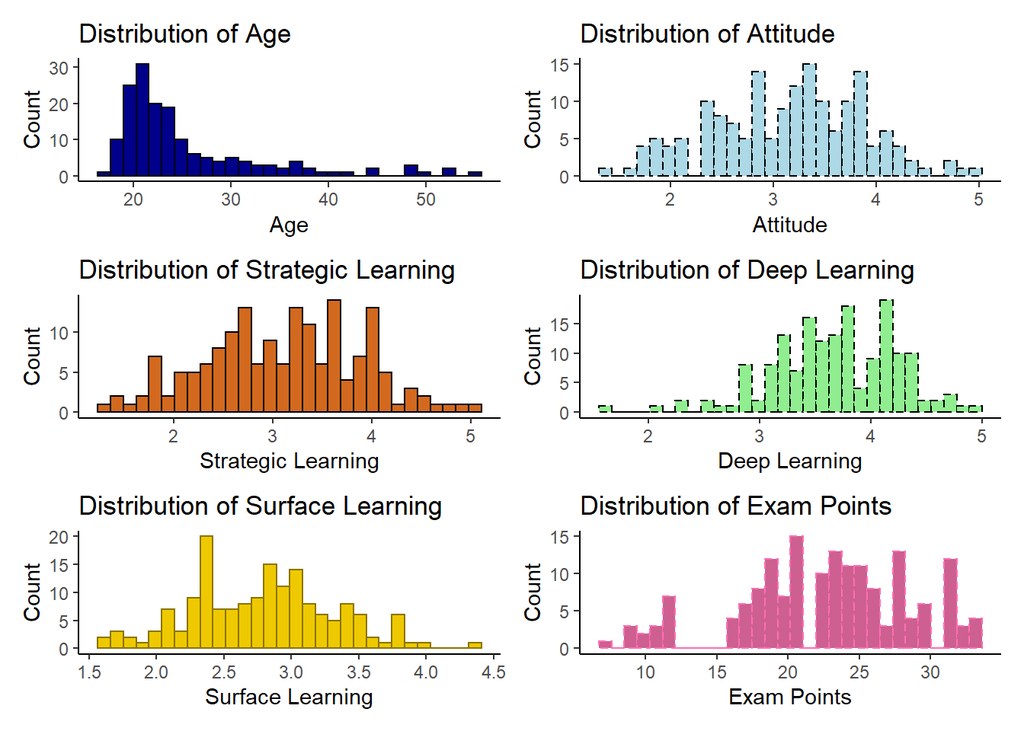

```r
data <- read.table("https://raw.githubusercontent.com/KimmoVehkalahti/Helsinki-Open-Data-Science/master/datasets/learning2014.txt", sep=",", header=TRUE)

library(ggplot2)
library(patchwork)

# Distribution of Age
a <- ggplot(data, aes(x = age))+
  geom_histogram(color = "black", fill = "darkblue", bins = 30) +
  labs(title="Distribution of Age",x="Age", y = "Count") +
  theme_classic()

# Distribution of Attitude
b <- ggplot(data, aes(x = attitude))+
  geom_histogram(color="black", fill="lightblue",linetype="dashed", bins = 30) +
  labs(title="Distribution of Attitude",x="Attitude", y = "Count") +
  theme_classic()

# Distribution of Strategic Learning
c <- ggplot(data, aes(x = stra))+
  geom_histogram(color = "black", fill = "chocolate", bins = 30) +
  labs(title="Distribution of Strategic Learning",x="Strategic Learning", y = "Count") +
  theme_classic()

# Distribution of Deep Learning
d <- ggplot(data, aes(x = deep))+
  geom_histogram(color="black", fill="lightgreen",linetype="dashed", bins = 30) +
  labs(title="Distribution of Deep Learning",x="Deep Learning", y = "Count") +
  theme_classic()

# Distribution of Surface Learning
e <- ggplot(data, aes(x = surf))+
  geom_histogram(color="gold4", fill="gold2", bins = 30) +
  labs(title="Distribution of Surface Learning",x="Surface Learning", y = "Count") +
  theme_classic()

# Distribution of Exam Points
f <- ggplot(data, aes(x = points))+
  geom_histogram(color="hotpink1", fill="hotpink3",linetype="dashed", bins = 30) +
  labs(title="Distribution of Exam Points",x="Exam Points", y = "Count") +
  theme_classic()

(a + b) / (c+d) /(e+f)
```

Through these histograms, we can see that age lies on a positively skewed distribution. Deep learning shows a lit bit of a negatively skewed distribution. Distribution of attitude and the distribution of the strategic learning shows normal yet multi-mode distribution. The distribution of surface learning lies on slightly positive skewed distribution. The distribution of exam points is not clearly visible.

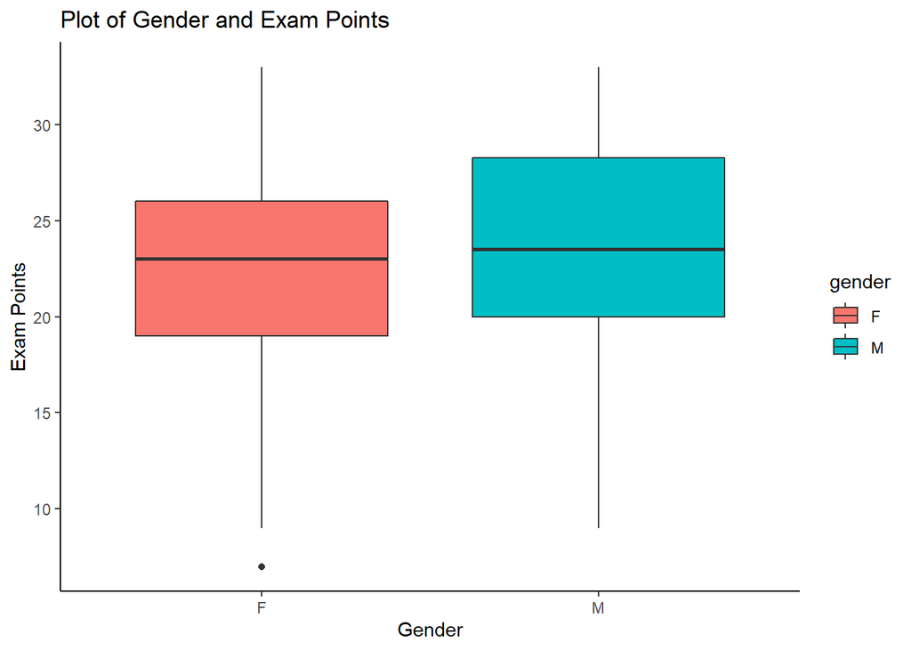

```r
# Gender and Exam Points

p1 <- ggplot(data, aes(x = gender, y = points, fill = gender)) +
  labs(title="Plot of Gender and Exam Points",x="Gender", y = "Exam Points") +
  theme_classic()

p2 <- p1 + geom_boxplot()
p2
```

The median exam points of both males and females are quite similar to each other. But the female exam points are left skewed while the male exam points are right skewed. There is one outlier in the female category.

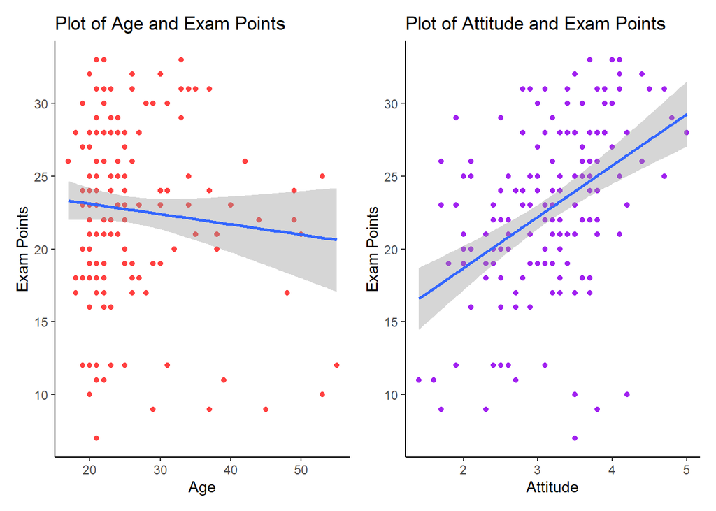

```r
# Age and Exam Points

a1 <- ggplot(data, aes(x = age, y = points)) +
  labs(title="Plot of Age and Exam Points",x="Age", y = "Exam Points")
a <- a1 + geom_point(colour = "brown1") + theme_classic() + geom_smooth(method = "lm")


# Attitude and Exam Points

b1 <- ggplot(data, aes(x = attitude, y = points)) +
  labs(title="Plot of Attitude and Exam Points",x="Attitude", y = "Exam Points")
b <- b1 + geom_point(colour = "purple") + theme_classic() + geom_smooth(method = "lm")

a + b
```

It is clear to see that there is a positive relationship between attitude and the exam points. There is no any clear linear relationship between age and the exam points. However, the regression line shows that there is a negative linear relationship between age and the exam points.

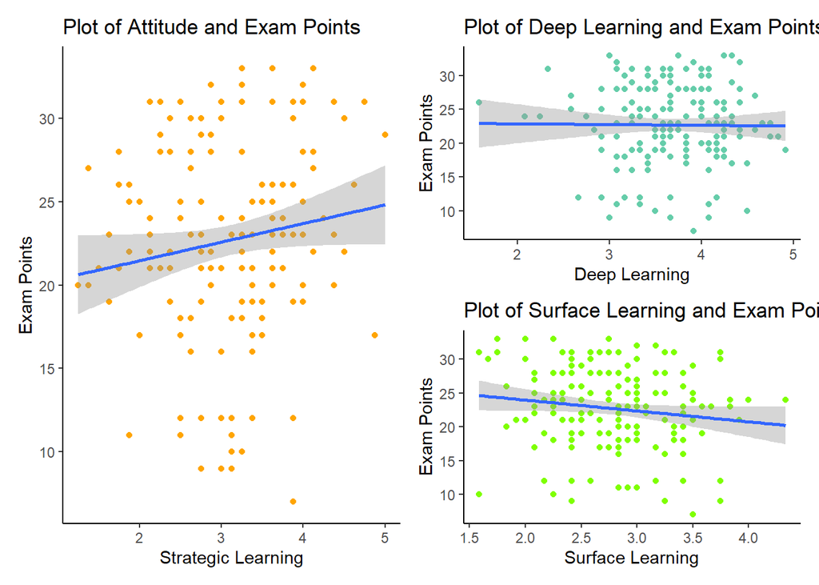

```r
# Strategic Learning and Exam Points

c1 <- ggplot(data, aes(x = stra,  y = points)) +
  labs(title="Plot of Attitude and Exam Points",x="Strategic Learning", y = "Exam Points")
c <- c1 + geom_point(colour = "orange") + theme_classic() + geom_smooth(method = "lm")


# Deep Learning and Exam Points

d1 <- ggplot(data, aes(x = deep, y = points)) +
  labs(title="Plot of Deep Learning and Exam Points",x="Deep Learning", y = "Exam Points")
d <- d1 + geom_point(colour = "aquamarine3") + theme_classic() + geom_smooth(method = "lm")


# Surface Learning and Exam Points

e1 <- ggplot(data, aes(x = surf, y = points)) +
  labs(title="Plot of Surface Learning and Exam Points",x="Surface Learning", y = "Exam Points")
e <- e1 + geom_point(colour = "chartreuse") + theme_classic() + geom_smooth(method = "lm")

c+d/e
```

There is a weak positive linear relationship between strategic learning and the exam points. There is no any clear linear relationship between deep learning and the exam points. However, the regression line shows that there is a weak negative linear relationship between deep learning nd exam points. There is a weak negative linear relationship between surface learning and the exam points.

## Model Fitting and Interpretation

```r
# Model 1

Model1 <- lm(points ~ attitude + stra + deep, data = data)
summary(Model1)
```

```
##
## Call:
## lm(formula = points ~ attitude + stra + deep, data = data)
##
## Residuals:
##      Min       1Q   Median       3Q      Max
## -17.5239  -3.4276   0.5474   3.8220  11.5112
##
## Coefficients:
##             Estimate Std. Error t value Pr(>|t|)
## (Intercept)  11.3915     3.4077   3.343  0.00103 **
## attitude      3.5254     0.5683   6.203 4.44e-09 ***
## stra          0.9621     0.5367   1.793  0.07489 .
## deep         -0.7492     0.7507  -0.998  0.31974
## ---
## Signif. codes:  0 '***' 0.001 '**' 0.01 '*' 0.05 '.' 0.1 ' ' 1
##
## Residual standard error: 5.289 on 162 degrees of freedom
## Multiple R-squared:  0.2097, Adjusted R-squared:  0.195
## F-statistic: 14.33 on 3 and 162 DF,  p-value: 2.521e-08
```

Call: Here it shows our explanatory variables: “attitude”, “strategic learning (stra)” and “Deep learning (deep)” and the dependent variable:“exam points (points).

Residuals: The residuals are the difference between the actual values and the predicted values. It is good to see that the median value is near to zero (0.5474), as this would tell us our residuals are somewhat symmetrical and that our model is predicting evenly at both the high and low ends of our dataset. Even though this dataset is slightly left-skewed, it is almost shows a normal distribution.

Coefficients:

Regarding the estimates,

Y = 11.3915 + 3.5254(x1) + 0.9621(x2) - 0.7492(x3) Here x1 means the attitude, x2 means the strategic learning and the x3 means deep learning.

Even without any of the attitude, strategic learning and deep learning, the students would score 11.39 points for the exam.Then, for one additional unit of attitude, the exam points will increase by 3.53 (when strategic learning and deep learning is constant). For one additional unit of strategic learning, the exam points will increase only by 0.96 (when attitude and deep learning is constant). For one additional unit of deep learning, the exam points will decrease by 0.75 (when strategic learning and attitude is constant).

Regarding the standard error,

This shows the standard deviation of the coefficient. Through this we can get an idea about the uncertainty of the coefficient. The standard error is used to create confidence intervals.

Looking at the confidence interval, it is clear with 95% confident that the actual slope (attitude) is between (3.5254 ± 1.96(0.5683)) = 2.41 and 4.64. Looking at the confidence interval, it is clear with 95% confident that the actual slope (strategic learning) is between (0.9621 ± 1.96(0.5367)) = -0.09 and 2.01. Looking at the confidence interval, it is clear with 95% confident that the actual slope (deep learning) is between (-0.7492 ± 1.96(0.7507)) = -2.22 and 0.722.

Regarding the t-value,

It is the value of coefficient divided by the standard error. It is always better to large t-statistics, because it indicates that the standard error is small in comparison to the coefficient. Compared to the strategic learning and the deep learning, the t valu of attitude is far from 0, indicating that the coefficient is not zero.

Regarding the Pr(>|t|),

This is calculated using the t-statistic from the T distribution, to understand how significant the coefficient is to the model. In general p < 0.05, is believed to be significant: the coefficient add value to the model by helping to explain the variance within the dependent variable. In this model, it is showed that only the “attitude” variable is significant under 0.05. The “strategic learning (stra)” and the “deep learning (deep)” is not significant under 0.05.

Thus, I decided to drop both the variables: stra and deep to further analysis purpose.

```r
# Model 2

Model2 <- lm(points ~ attitude , data = data)
summary(Model2)
```

```
##
## Call:
## lm(formula = points ~ attitude, data = data)
##
## Residuals:
##      Min       1Q   Median       3Q      Max
## -16.9763  -3.2119   0.4339   4.1534  10.6645
##
## Coefficients:
##             Estimate Std. Error t value Pr(>|t|)
## (Intercept)  11.6372     1.8303   6.358 1.95e-09 ***
## attitude      3.5255     0.5674   6.214 4.12e-09 ***
## ---
## Signif. codes:  0 '***' 0.001 '**' 0.01 '*' 0.05 '.' 0.1 ' ' 1
##
## Residual standard error: 5.32 on 164 degrees of freedom
## Multiple R-squared:  0.1906, Adjusted R-squared:  0.1856
## F-statistic: 38.61 on 1 and 164 DF,  p-value: 4.119e-09
```

Call: Here it shows our explanatory variables: “attitude” and the dependent variable:“exam points (points).

Residuals: As the median value is near to zero (0.4339), the residuals are somewhat symmetrical. This model predicts evenly at both the high and low ends of the dataset. Even though this dataset is slightly left-skewed, it is almost shows a normal distribution.

Coefficients:

Regarding the standard error,

This shows the standard deviation of the coefficient. Through this we can get an idea about the uncertainty of the coefficient. The standard error is used to create confidence intervals.

## Diagnostic Plots

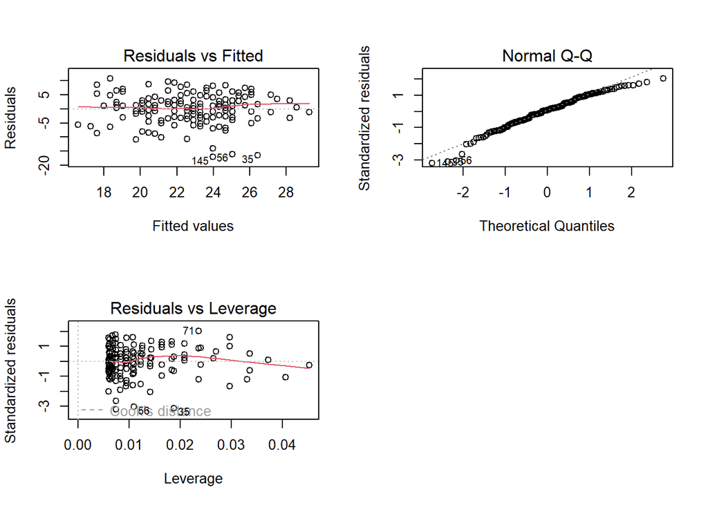

```r
par(mfrow = c(2,2))
plot(Model2, which = c(1,2,5))
```